# ChIP-seq Analysis

The analysis below studies the binnding sites of COUP-TFII also refered as NR2F2. The data was collected from GEO https://www.ncbi.nlm.nih.gov/geo/query/acc.cgi?acc=GSE52008. ChIP-seq was performed on human endometrial stromal cells (HESC) treated with deciduogenic hormones using an antibody against COUP-TFII. As input, inmunoprecipitation with normal rabbit IgG was performed.

### Biological system

https://www.cell.com/cancer-cell/fulltext/S1535-6108(18)30127-2#figures

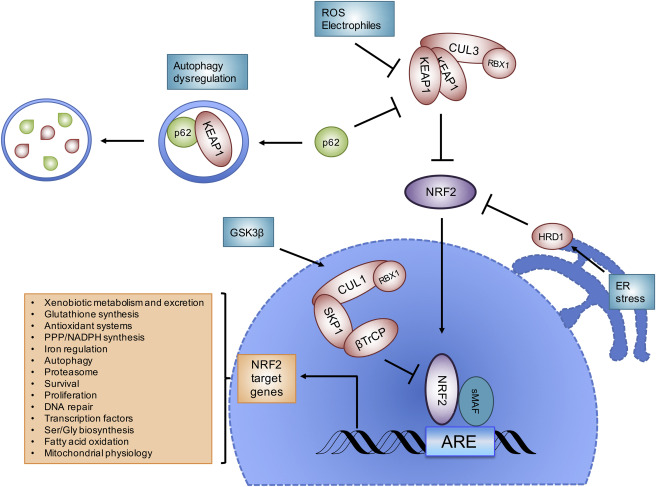

Precise control of inflammation plays a very important role in maintaining a well-balanced immune response and preventing a persistent state of inflammation. The nuclear factor erythroid 2-like 2 (NRF2) also know as Chicken ovalbumin upstream promoter-transcription factor II (COUP-TFII) serves as a key mediator in controlling inflammation [1]. When stabilized due to oxidative stress, NRF2 triggers the expression of antioxidants and genes that protect cells, leading to an anti-inflammatory effect essential for the body's healing process [2]. As we known, overactivation or underactivation of NRF2 is involved in the development of chronic diseases due to its important role regulating inflamatory responses.

NRF2 operates by binding to specific sequences known as AREs (antioxidant response elements) in the DNA of cells, as shown in the figure above [2]. These AREs are regions in the DNA that regulates the transcription of genes responsible for antioxidants and detoxification enzymes [2]. The activation of these genes helps the cell combat oxidative stress, maintain redox balance, and defend against harmful molecules known as reactive oxygen species [2]. Furthermore, it is known that NRF2 is involved in some of the following processes: cell-fate specification, organogenesis, angiogenesis and metabolism [1].

Some studies have studied the role of this transcription factor in the female reproduction by studying mice but its role in humans remains unknown that is why the autors of this experiment decided to studied it [1]. The role of NRF2 in the uterous may give us insight to better understand Endometriosis, a very common desease affecting women. This is characterize by chronic pelvic pain and it is associated with progesteron insensitivity (result from the deregulation of the progesterone receptor, steroid receptor coactivators etc). Prevous studies found that mice lacking NRF2, down-regulate stromal progesterone receptors. This may suggest that this transcription factor plays an important role in progesterone resistance in women with the disease [1]. In fact, in the same study [1], after doing a differential expression analysis, they found that NRF2 is highly expressed in endometrial stoma of healthy women while the expression is reduced in women with endometriosis [1]. Due to this, it is of great interest to know more about the interaction of this transcription factor with the DNA by chIP-seq analysis.

### Experiment design

Pooled primary human endometrial stromal cells from 6 healthy women upon decidualization with a hormone cocktail of cAMP, E2 and medroxyprogesterone acetate where analysed in the presence of antibodies for COUP-TFII (N2RF2). The data set of this study consists of two samples, as shown in the following image.

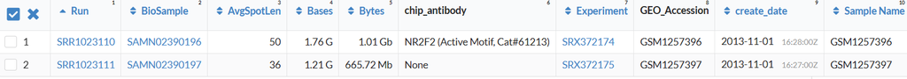

### ChIP-seq details

The experiment was done using Illumina Genome Analyzer II to obtain the sequencing results. Single reads were obtained.

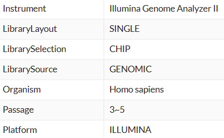

### Downloading the sample containing the antibody and QC Quality control

First, the sample containing the antibody was analyzed. The following code lines do:

- Download the reads in a fastq format
- Quality assessment using fastqc command

```bash
fastq-dump -X 5 -Z SRR1023110
```

```
Read 5 spots for SRR1023110
Written 5 spots for SRR1023110
@SRR1023110.1 HWI-ST619:255:D19YDACXX:3:1101:1232:1973 length=50
TTATGTGAAGATATTTCCTTCTCCACCATAGCCCTCAAAGCGCNCCAAGT
+SRR1023110.1 HWI-ST619:255:D19YDACXX:3:1101:1232:1973 length=50
CC@FFFFDFHFHHIIJGIJJGHHJJIJJJJJHIJIIJJJIIJI#0?GFID
@SRR1023110.2 HWI-ST619:255:D19YDACXX:3:1101:1494:2000 length=50
AGGGCCGACTTCACCCGGCGAGGACAGGGCGAGGCGCTGGGCCCAGAGGT
+SRR1023110.2 HWI-ST619:255:D19YDACXX:3:1101:1494:2000 length=50
@@CFFADD<FHGAGCIIBGHDHAA;@GGGIIEFCCCBBBCCCBCBB8AB>
@SRR1023110.3 HWI-ST619:255:D19YDACXX:3:1101:1463:2000 length=50
CTCATGCCTGTAATTCCAGCACTTTGGGAGTCCAAAGCAGGAGTTCAAGA
+SRR1023110.3 HWI-ST619:255:D19YDACXX:3:1101:1463:2000 length=50
??<?D+:BD?2:CBE:E:A:;3AFEDFI3<)1:9CE?:9?D:B)90*?B?
@SRR1023110.4 HWI-ST619:255:D19YDACXX:3:1101:1918:1968 length=50
NACAACAGCAAGCAGTAAAGTTTCTGTGTNCTATCTTTTATGTNTTTTAT
+SRR1023110.4 HWI-ST619:255:D19YDACXX:3:1101:1918:1968 length=50
#1=DDFFFHHGHHJJHIJJJIIJJJJEHH#1?DGHIJJJIJJG#0?GHHI
@SRR1023110.5 HWI-ST619:255:D19YDACXX:3:1101:1897:1971 length=50
TGTCAGGGAGTTTCATATCCCAGAACAGTNATGGGAGTGAGTANCTGGGA
+SRR1023110.5 HWI-ST619:255:D19YDACXX:3:1101:1897:1971 length=50
??;DDDDD?8+AD,A?<:CFE9BEECECA#)11?D1??;?B9?#001BD2
```

```bash
mkdir -p /mnt/storage/$USER/jupyternotebooks/Chip-seq/
```

```
0
```

```bash
cd /mnt/storage/$USER/jupyternotebooks/Chip-seq/
```

```bash
fastq-dump -O /mnt/storage/r0870275/jupyternotebooks/Chip-seq SRR1023110
```

```
Read 35284736 spots for SRR1023110
Written 35284736 spots for SRR1023110
```

```bash
cd /mnt/storage/$USER/jupyternotebooks/Chip-seq/
```

```bash
fastqc *.fastq
```

[output not shown]

The per base sequence quality looks good!

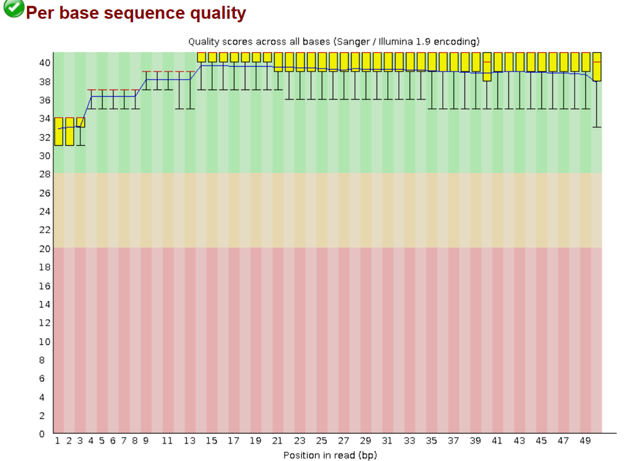

```bash
ls -lt | head
```

[output not shown]

### Aligning the sequences to the human genome (hg19)

For this, the bowtie2 tool was used using the human genome already provided in the resorces folder for this course. As it shows, the alignment rate for the sample was good (98.54%) this means which means the majority of the reads successfully aligned to the reference genome used in the alignment process. 78.74% of the reads were aligned one time to the genome, this is an aceptable rate.

```bash
bowtie2 -x /mnt/storage/data/resources/bowtie2/hg19 SRR1023110.fastq -S SRR1023110.sam
```

```
35284736 reads; of these:
  35284736 (100.00%) were unpaired; of these:
    515153 (1.46%) aligned 0 times
    27782756 (78.74%) aligned exactly 1 time
    6986827 (19.80%) aligned >1 times
98.54% overall alignment rate
```

```bash
head -500 SRR1023110.sam | tail -5
```

```
SRR1023110.410	0	chr5	53720073	42	50M	*	0	0	CGAAATGCCTGTGCCAACCGCCTGGCATTTTCCTCCATTTTCATGGCACT	CCCFFFFFHHHHHJJJJJJJJJJJJJJJJJJIJJIJGIJJJIJJJJIJJJ	AS:i:0	XN:i:0	XM:i:0	XO:i:0	XG:i:0	NM:i:0	MD:Z:50	YT:Z:UU
SRR1023110.411	0	chr9	139870741	42	50M	*	0	0	GTGCTGCCCACTAGCCCCTGCTGCTACATAGGCATGCGCCTCCCCCAGTC	CCCFFFFFHHHHHJJJJJJJJJJJJJJJJJJJJJJJJJIJJIJJJJJJIG	AS:i:0	XN:i:0	XM:i:0	XO:i:0	XG:i:0	NM:i:0	MD:Z:50	YT:Z:UU
SRR1023110.412	0	chr2	194549802	42	50M	*	0	0	ATTTTCTTATAATCAGCATAACATGAGTAATATATGTGAAGTCTTTTCCT	CCCFFFFFHHHHHJJJJJJJJJIJJGJHIJJJJJJJIJJJJIJIJJJJJI	AS:i:0	XN:i:0	XM:i:0	XO:i:0	XG:i:0	NM:i:0	MD:Z:50	YT:Z:UU
SRR1023110.413	16	chr7	96775776	42	50M	*	0	0	TGTGATCGTATAAATGTTACAAAAAGAACATAAAATAATTGTTCTTGAGA	JJJJJJJJJJJJJJJJJIIJJJJJJGJJJJJJJJJJJHHHHHFFFFFCCC	AS:i:0	XN:i:0	XM:i:0	XO:i:0	XG:i:0	NM:i:0	MD:Z:50	YT:Z:UU
SRR1023110.414	0	chr2	161887226	42	50M	*	0	0	GAGCATGAAGAACGTTGTATACTGGTGTGTTAGGCAAGAACTTTTTGGTT	CCCFFFFFHHHHHJIJJIIJJJJJJFHFHHIIJJJJJJIJJJJJJJJJHI	AS:i:0	XN:i:0	XM:i:0	XO:i:0	XG:i:0	NM:i:0	MD:Z:50	YT:Z:UU
```

```bash
samtools view -S -b SRR1023110.sam > SRR1023110.bam
```

```bash
rm SRR1023110.sam
```

The total number of reads is 35284736

```bash
samtools view -c SRR1023110.bam
```

```
35284736
```

The total of mapped reads can be obtained by the flag 260 (will count the number of primary alignments (not secondary) and mapped reads (not unmapped)), with this the number of reads decreases to 34769583

```bash
samtools view -b -h -F 260 SRR1023110.bam > SRR1023110_filtered.bam
```

```bash
samtools view -c SRR1023110_filtered.bam
```

```
34769583
```

First the sorted and index files are computed using samtools commands.

```bash
samtools sort -O bam -o SRR1023110.sorted.bam SRR1023110_filtered.bam
```

```
[bam_sort_core] merging from 8 files and 1 in-memory blocks...
```

```bash
samtools index SRR1023110.sorted.bam
```

```bash
ls
```

```
SRR1023110.bam    SRR1023110_fastqc.html  SRR1023110.sorted.bam
SRR1023110.fastq  SRR1023110_fastqc.zip   SRR1023110.sorted.bam.bai
```

### Analysing the input file

The same process of downloading the data, looking into the QC quality and aligning the reads to the genome is done for the input file (sample without the antibody)

```bash
fastq-dump -X 5 -Z SRR1023111
```

```
Read 5 spots for SRR1023111
Written 5 spots for SRR1023111
@SRR1023111.1 ILLUMINA-EAS45:120:64CFWAAXX:1:1:1171:1070 length=36
TTGCATAGCAAGACATTATTGCCCTTCAGCCTGGCA
+SRR1023111.1 ILLUMINA-EAS45:120:64CFWAAXX:1:1:1171:1070 length=36
GBGGGGG@GGEE38BEEDEEGGGG@E8<=EE<EEEG
@SRR1023111.2 ILLUMINA-EAS45:120:64CFWAAXX:1:1:1300:1061 length=36
AATCAGGCAGTCTTGTTGAATACANCTTCAAGGTAT
+SRR1023111.2 ILLUMINA-EAS45:120:64CFWAAXX:1:1:1300:1061 length=36
@8;@@:8BB<D=DBBDDBBD?BBB#?6;6;DB?@DD
@SRR1023111.3 ILLUMINA-EAS45:120:64CFWAAXX:1:1:1583:1070 length=36
GTTGCGTGAGTTTGCACATGACCCCATCCAAGCCTG
+SRR1023111.3 ILLUMINA-EAS45:120:64CFWAAXX:1:1:1583:1070 length=36
HHEHHHHHHHHHHHHGFGGGGHHHGBGEGDGEEEDD
@SRR1023111.4 ILLUMINA-EAS45:120:64CFWAAXX:1:1:1634:1062 length=36
GGAATTATCATCGAATGGAATCGANTGGTATCAACA
+SRR1023111.4 ILLUMINA-EAS45:120:64CFWAAXX:1:1:1634:1062 length=36
GGDGGGIIIIIIIFIGGGEBB@D?#?BB;<GGEFFH
@SRR1023111.5 ILLUMINA-EAS45:120:64CFWAAXX:1:1:1770:1065 length=36
GGACAAAATCCCAACTGGCACCAANACAACAAAATT
+SRR1023111.5 ILLUMINA-EAS45:120:64CFWAAXX:1:1:1770:1065 length=36
HHHGHHDHHHHHHHHHHHHFEECC#<B:==DDDDDH
```

```bash
fastq-dump -O /mnt/storage/r0870275/jupyternotebooks/Chip-seq SRR1023111
```

```
Read 33513636 spots for SRR1023111
Written 33513636 spots for SRR1023111
```

```bash
fastqc SRR1023111.fastq
```

[output not shown]

For this sample the per base sequence quality is also pretty good!

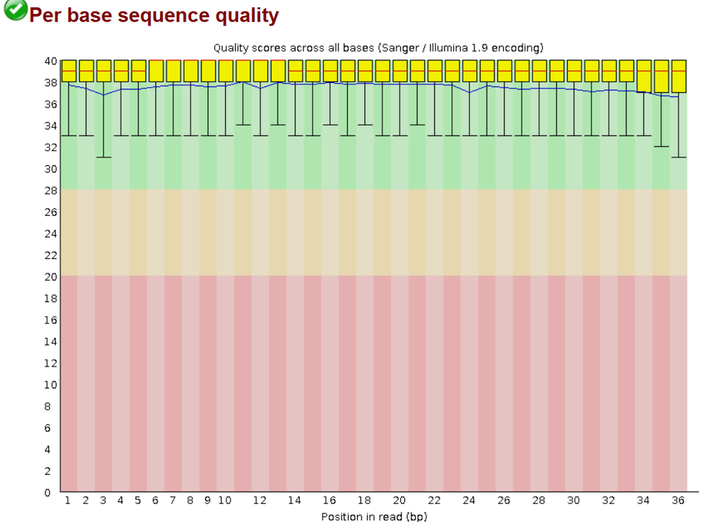

The alignment rate for the sample is similar to the other sample (96.07%)

```bash
bowtie2 -x /mnt/storage/data/resources/bowtie2/hg19 SRR1023111.fastq -S SRR1023111.sam
```

```
33513636 reads; of these:
  33513636 (100.00%) were unpaired; of these:
    1318474 (3.93%) aligned 0 times
    24374738 (72.73%) aligned exactly 1 time
    7820424 (23.34%) aligned >1 times
96.07% overall alignment rate
```

```bash
head -500 SRR1023111.sam | tail -5
```

```
SRR1023111.410	0	chr2	65868995	42	36M	*	0	0	GTTTTATAAAAAAAAAAACCTTGAGGCAATTAGGGC	IIIIIIIIIIIIIIIIIIIIIIIHIGEIIIIIGIHE	AS:i:0	XN:i:0	XM:i:0	XO:i:0	XG:i:0	NM:i:0	MD:Z:36	YT:Z:UU
SRR1023111.411	16	chr7	107770028	38	36M	*	0	0	GCTGTAGTACAGTGGCACATTCTTGGTTCACTGCAA	IIHHIIIIIIIIIIIIIIIIIIIIIIIIIIIIHIII	AS:i:0	XS:i:-18	XN:i:0	XM:i:0	XO:i:0	XG:i:0	NM:i:0	MD:Z:36	YT:Z:UU
SRR1023111.412	4	*	0	0	*	*	0	0	CGTGACATTCAGAAGGGTAATAAGAACGAACCATAA	HHHHHHHHHHBGGEGGGBGEGE>GDHHHFHHHHHGH	YT:Z:UU
SRR1023111.413	0	chr15	36033797	42	36M	*	0	0	AATGTAAACGTTGCTACTGCAGCAACCCTGGAGATT	GGHHHEGGGGHHHHEGGGGGEGGEGHHHGHG8BBGG	AS:i:0	XN:i:0	XM:i:0	XO:i:0	XG:i:0	NM:i:0	MD:Z:36	YT:Z:UU
SRR1023111.414	0	chr19	23306099	1	36M	*	0	0	CGGTGGCTCACGCCTGTAATCCCAGCACTTTGGGAG	IIHFIIIIIGIIIIIHIGIHIIIIHIIHIIIIIHGI	AS:i:0	XS:i:0	XN:i:0	XM:i:0	XO:i:0	XG:i:0	NM:i:0	MD:Z:36	YT:Z:UU
```

```bash
samtools view -S -b SRR1023111.sam > SRR1023111.bam
```

```bash
rm SRR1023111.sam
```

```
rm: cannot remove 'SRR1023111.sam': No such file or directory
```

```bash
samtools view -c SRR1023111.bam
```

```
33513636
```

```bash
samtools view -b -h -F 260 SRR1023111.bam > SRR1023111_filtered.bam
```

```bash
samtools view -c SRR1023111_filtered.bam
```

```
32195162
```

After filtering we have 32195162 reads for the input file

The sorted and index files for this sample are obtained so it can be visualized in IGV toguether with the other sample in the following step.

```bash
samtools sort -O bam -o SRR1023111.sorted.bam SRR1023111_filtered.bam
```

```
[bam_sort_core] merging from 7 files and 1 in-memory blocks...
```

```bash
samtools index SRR1023111.sorted.bam
```

Creating the coverage file of the reads, this can also be visualized using IGV

```bash
bamCoverage -b SRR1023110.sorted.bam --normalizeUsing RPGC --effectiveGenomeSize 2864785220 -o full.bw
```

```
normalization: 1x (effective genome size 2864785220)
bamFilesList: ['SRR1023110.sorted.bam']
binLength: 50
numberOfSamples: None
blackListFileName: None
skipZeroOverZero: False
bed_and_bin: False
defaultFragmentLength: read length
numberOfProcessors: 1
verbose: False
region: None
bedFile: None
minMappingQuality: None
ignoreDuplicates: False
chrsToSkip: []
stepSize: 50
center_read: False
samFlag_include: None
samFlag_exclude: None
minFragmentLength: 0
maxFragmentLength: 0
zerosToNans: False
smoothLength: None
save_data: False
out_file_for_raw_data: None
maxPairedFragmentLength: 1000
```

### Peak Visualization with IGV

IGV one of the detected peaks was visualized. The peak is located in the IGF1R gene. This gene is a target gene of the COUP-TFII transcription factor and is associated with focal adhesion [1]. This is a good sign of data quality. It can be seen the difference in the number of reads between the positive sample and the control (input sample). In purple we can see the coverage of the positive sample. The reads in both samples were colored by strand (red and blue colors). As a quality control measure it is observed that in the peak the number of blue and red reads is similar.

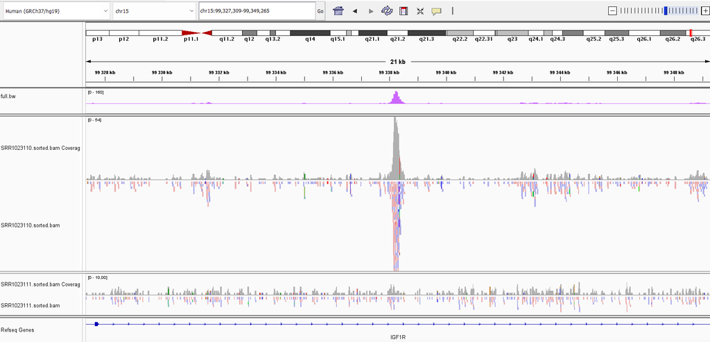

### Peak calling using MACS2

In order to identify the true peaks in the analysis one of the tools available for these is macs2. As inputs it takes the sorted bam files of the positive and control samples. A p-value of 1e-10 was specified. Although this value is pretty strict, it was implemented given a high number of detected peaks with higher p-values. Using such a small p-value suggests that the identified peaks are likely to be biologically meaningful and not just random noise or background signal. Also, this was the p-value implemented in the reference study [1].

A total of 10364 peaks were identified, given that this number is very high the number of peaks was reduced to the 3000 most significant ones. From the narrowPeaks file the bed file was obtained.

```bash
export OMP_NUM_THREADS=20
macs2 callpeak -t SRR1023110.sorted.bam -c SRR1023111.sorted.bam -n NR2F2 -g hs -p 1e-10
```

[output not shown]

[output cut: 68 more lines]

```
INFO  @ Tue, 05 Dec 2023 02:15:51: start model_add_line...
INFO  @ Tue, 05 Dec 2023 02:15:53: start X-correlation...
INFO  @ Tue, 05 Dec 2023 02:15:53: end of X-cor
INFO  @ Tue, 05 Dec 2023 02:15:53: #2 finished!
INFO  @ Tue, 05 Dec 2023 02:15:53: #2 predicted fragment length is 139 bps
INFO  @ Tue, 05 Dec 2023 02:15:53: #2 alternative fragment length(s) may be 139 bps
INFO  @ Tue, 05 Dec 2023 02:15:53: #2.2 Generate R script for model : NR2F2_model.r
INFO  @ Tue, 05 Dec 2023 02:15:53: #3 Call peaks...
INFO  @ Tue, 05 Dec 2023 02:15:53: #3 Call peaks with given -log10pvalue cutoff: 10.00000 ...
INFO  @ Tue, 05 Dec 2023 02:15:53: #3 Pre-compute pvalue-qvalue table...
INFO  @ Tue, 05 Dec 2023 02:20:52: #3 Call peaks for each chromosome...
INFO  @ Tue, 05 Dec 2023 02:23:25: #4 Write output xls file... NR2F2_peaks.xls
INFO  @ Tue, 05 Dec 2023 02:23:25: #4 Write peak in narrowPeak format file... NR2F2_peaks.narrowPeak
INFO  @ Tue, 05 Dec 2023 02:23:25: #4 Write summits bed file... NR2F2_summits.bed
INFO  @ Tue, 05 Dec 2023 02:23:25: Done!
```

```bash
Rscript NR2F2_model.r
```

```bash
cat NR2F2_peaks.narrowPeak | wc -l
```

```
10364
```

```bash
cat NR2F2_peaks.narrowPeak | cut -f 1-3 > all_peaks.narrowPeak.bed
```

```bash
cat NR2F2_peaks.narrowPeak | sort -k9 -g -r | head -3000 > NR2F2_cutpeaks.narrowPeak
```

```
sort: write failed: 'standard output': Broken pipe
sort: write error
```

```bash
cat NR2F2_cutpeaks.narrowPeak | cut -f 1-3 > cut_peaks.narrowPeak.bed
```

```bash
cat cut_peaks.narrowPeak.bed | wc -l
```

```
3000
```

```bash
computeMatrix reference-point \
    -S full.bw \
    -R cut_peaks.narrowPeak.bed \
    --referencePoint center \
    -a 3000 \
    -b 3000 \
    --binSize 5 \
    -out cut_peaks.tab.gz
```

```bash
plotHeatmap \
    -m cut_peaks.tab.gz \
    -out cut_peaks.png \
    --heatmapHeight 15  \
    --refPointLabel peak.center \
    --regionsLabel peaks \
    --plotTitle 'ChIP-seq signal'
```

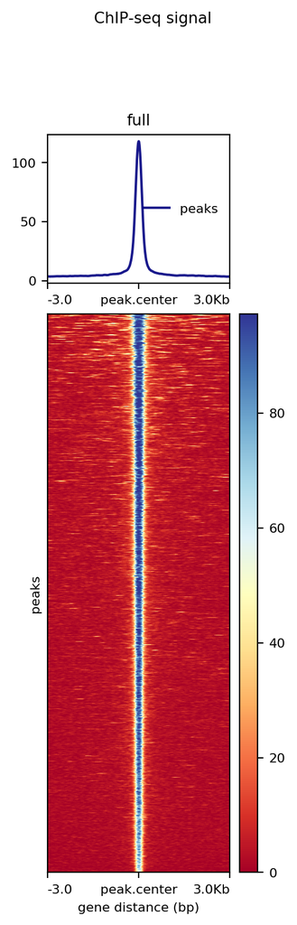

### The novo Motifs analysis

First, the bed file containing the peaks selected in the step above is converted to a fasta file using bedtools getfasta command. RSAT software is going to be used search for motifs according to the input peaks. HOMOMOCO database was selected for human transcription factors. The results from RSAT can be seen in the following link: https://jupyter.gbiomed.kuleuven.be/user/r0870275/view/Chip-seq/peak-motifs_synthesis.html

The first hit corresponds to NRF2 (COT2) motif, this corresponds to the NRF2 motif, as expected! The significance is very high.

From the 3000 peaks selected 25% (758 direct peaks) of these contain this motif. This number is lower than expected but can be due to the fact that the totality of the peaks is not being used, and that only the higer 3000 peaks were selected.

The AAAGGTCA motif found by RSAT correspond to the exact motif found by the reference study [1].

```bash
bedtools getfasta -fi /mnt/storage/data/resources/hg19/hg19.fa -bed cut_peaks.narrowPeak.bed -fo cut_peaks.fasta
```

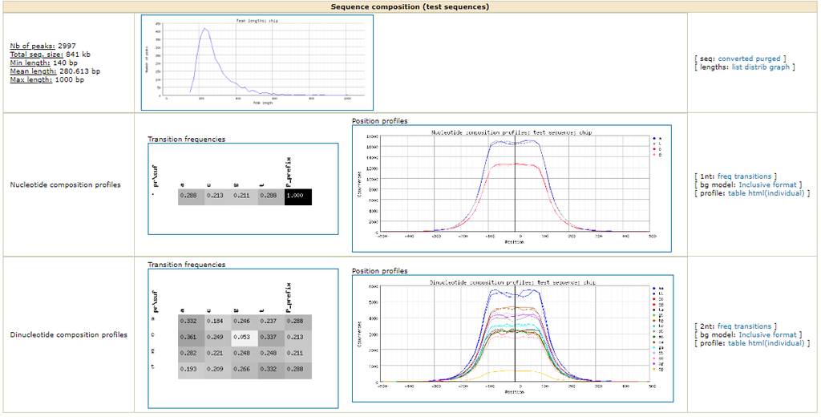

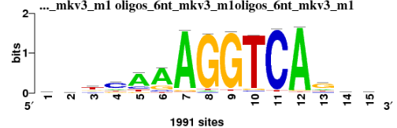

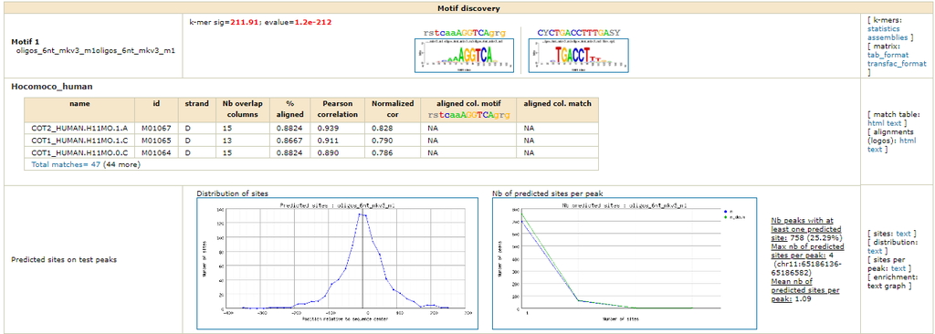

```bash
grep -v ";" peak-motifs_oligos_6nt_mkv3_m1_sites.tab | grep -v '#' | head -n 2
```

```
chr11:92066058-92066504	site	oligos_6nt_mkv3_m1oligos_6nt_mkv3_m1	D	-52	-38	GCTCCAAGGTCAAGC	8.2
chr12:47496937-47497403	site	oligos_6nt_mkv3_m1oligos_6nt_mkv3_m1	D	-156	-142	ATTTATAGGTCACGC	8.6
grep: write error: Broken pipe
```

```bash
grep -v ";" peak-motifs_oligos_6nt_mkv3_m1_sites.tab | grep -v '#' | cut -f 1 | tr "_" "\t" | awk '!a[$0]++' | head
```

```
chr11:92066058-92066504
chr12:47496937-47497403
chr8:42575531-42576007
chr4:129439043-129439369
chr7:93759097-93759481
chr4:129271047-129271285
chr12:15782114-15782430
chr7:48179605-48179946
chr12:115732268-115732600
chr1:201885796-201886175
```

```bash
cat peak-motifs_oligos_6nt_mkv3_m1_sites.tab | grep -v ";" | grep -v '#' | cut -f 1 | tr "_" "\t" | awk '!a[$0]++' > NR2F2-allpeaks-with-motif-RSAT.bed
```

```bash
cat NR2F2-allpeaks-with-motif-RSAT.bed | wc -l
```

```
758
```

```bash
awk -F '[:-]' '{print $1 "\t" $2 "\t" $3 "\t" $4}' NR2F2-allpeaks-with-motif-RSAT.bed > NR2F2-allpeaks-with-motif-GREAT.bed
```

NR2F2-allpeaks-with-motif-GREAT.bed file will be used later in the workflow for linking the peaks to genes.

### PWM and track enrichment

the results of this analysis are found in the following link: https://gbiomed.kuleuven.be/apps/lcb/i-cisTarget/reports/9aed76dddef72a72064049e591f8b623c4ad01ca/report.html

Try this link if the other does not work: https://jupyter.gbiomed.kuleuven.be/user/r0870275/view/Chip-seq/i-cisTarget_%20results%20for%20chip.html

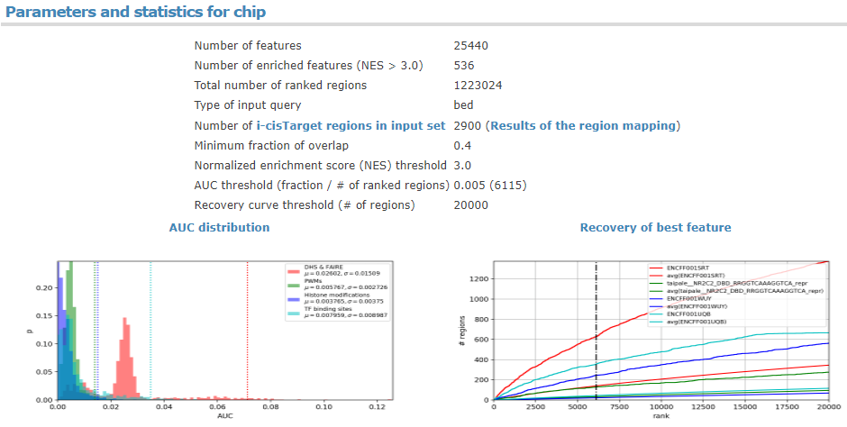

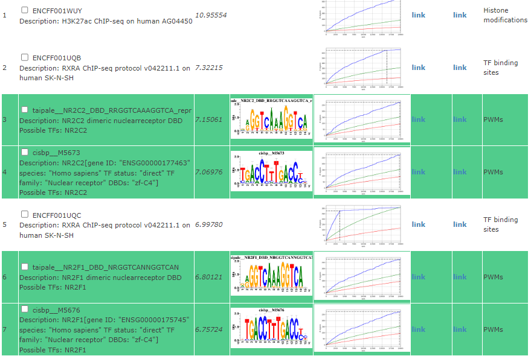

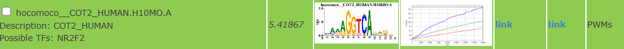

The first hits do not correspond to the NRF2 (COT2) motif. Although it was found further down (figure above). This could have happen given the characteristics of the TF studied. It is also important to mencioned that according to the refence study [1], NRF2 is considered an orphan TF. this, makes more dificult to perform an PWD analysis given that the binding usually is context-dependent. This means that their binding motifs and regulatory functions depend on celular conditions or specific cell types (endometrial stromal cells, in our case).

Given that the results from this where not as good as expected, only the peaks from the de novo motif discovery are going to be taken into account.

### Linking the results peaks to genes

[figure not shown]

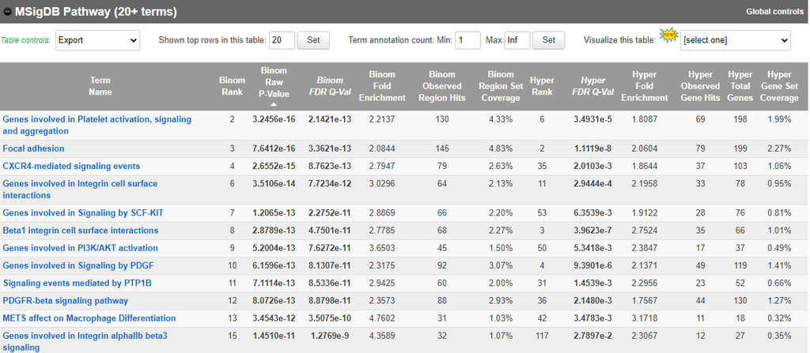

This results are similar to the pathways found by the authors of the data. As observed in the table below from the published paper based on the ChIP-seq data.

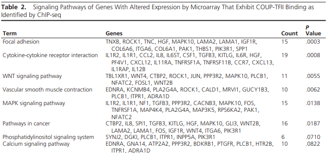

This are some of the genes for the cytokine-cytokine receptor interaction pathway.

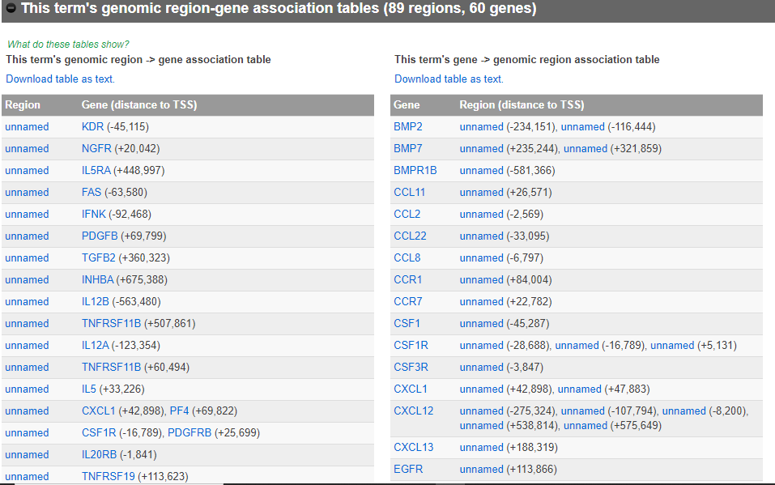

A .txt file containing all the genes linked to the peaks was downloaded and uploaded to the current working directory. The name of the file is 20231205-public-3.0.0-rK5X2b-hg19-all-gene.txt

As a data quality check, we found that the gene IGF1R is included, this is a good sign! since we knew from before that we had a peak on this gene when we were visualizing the peaks in IGV.

```bash
cat 20231203-public-3.0.0-fEbcqO-hg19-all-gene.txt | cut -f 1 | grep -v '#' > NRF2-targets-GREAT.txt
```

In total we have 3477 putative target genes from our enriched peaks.

```bash
cat 20231205-public-3.0.0-rK5X2b-hg19-all-gene.txt | cut -f 1 | grep -v '#' | wc -l
```

```
3477
```

As a quality measure we check that IGF1R, already visualized in IGV, is also here.

```bash
cat 20231205-public-3.0.0-rK5X2b-hg19-all-gene.txt | cut -f 1 | grep -v '#' | grep IGF1R
```

```
IGF1R
```

```bash
cat 20231205-public-3.0.0-rK5X2b-hg19-all-gene.txt | cut -f 1 | grep -v '#' > NRF2-targets-GREAT2.txt
```

The file of genes without header is saved in the NRF2-targets-GREAT2.txt

A network of other possible related genes for NRF2 was obtained using String Data base. The Figure belows shows the network, displaying NRF2 in red in the middle of the network.

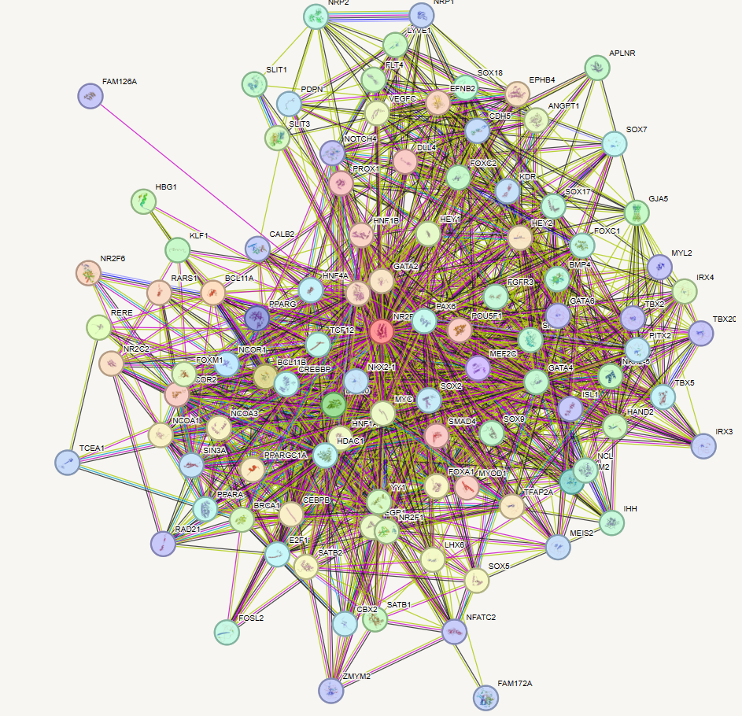

```bash
cat string_protein_annotations.tsv | cut -f1 | head
```

```
#node
AKT1
ANGPT1
APLNR
BCL11A
BCL11B
BMP4
BRCA1
CALB2
CBX2
```

```bash
cat string_protein_annotations.tsv | cut -f 1 | grep -v '#' > NRF2-string-top200.txt
```

```bash
list=`cat NRF2-string-top200.txt`
```

```bash
for i in $list; do grep -w $i NRF2-targets-GREAT2.txt; done
```

```
ANGPT1
BMP4
CDH5
CEBPB
CHRD
DLX2
EP300
ERBB4
FOSL2
FOXA1
FOXC1
GATA4
HAND2
HEY2
IRX3
JAG1
KDR
LYVE1
MBD2
MDM2
MEF2C
MEIS2
MYC
MYL2
NCOR2
NFATC2
NOTCH2
NR2F1
NR2F2
NRP1
NRP2
PDGFB
PDGFRA
PHC2
PPARA
PPARG
PPARGC1A
PROX1
RERE
SALL4
SATB2
SOX17
SOX5
SOX6
SOX7
TBX2
TBX3
TBX5
TCF12
VEGFC
ZFPM2
```

```bash
for i in $list; do grep -w $i NRF2-targets-GREAT2.txt; done > targets.txt
```

### Conclusions

The results of ChIP-seq analysis of the TF NRF2 (COUP-TFII) showed that this transcription factor act by directly binding to genes involved in pathways like integrin signalling, VEGF signaling, focal adhesion and cytokine-cytokine receptor interaction. These are related in general to cell adhesion, angiogenesis and inflamation which are hallmarks of endometriosis [1]. This confirms that the transcription factor studied here is involved with the development of the disease. The direct target genes identified by this analysis were also found in the related study [1].

# References

[1] Li X, Large MJ, Creighton CJ, Lanz RB, Jeong JW, Young SL, Lessey BA, Palomino WA, Tsai SY, Demayo FJ. COUP-TFII regulates human endometrial stromal genes involved in inflammation. Mol Endocrinol. 2013 Dec;27(12):2041-54. doi: 10.1210/me.2013-1191. Epub 2013 Oct 31. PMID: 24176914; PMCID: PMC3857200.

[2] Vomund S, Schäfer A, Parnham MJ, Brüne B, von Knethen A. Nrf2, the Master Regulator of Anti-Oxidative Responses. Int J Mol Sci. 2017 Dec 20;18(12):2772. doi: 10.3390/ijms18122772. PMID: 29261130; PMCID: PMC5751370.